# Prueba de hipótesis

Guillermo A. Durán

15 de junio de 2019

Este es un notebook para mostrar y explorar cómo realizar en R un análisis estadístico de comparación de dos promedios (*prueba de hipótesis*) utilizando tres técnicas distintas:

- de simulación (*permutaciones*),
- análisis frecuentista (*t-test* y modelo de regresión lineal) y
- análisis bayesiano:

Para el análisis utilizaremos el conjunto de datos *iris*.

```r
library(tidyverse)
library(datasets)
set.seed(1234)
data(iris)
iris %>% group_by(Species) %>% summarise(n = n())
```

```
## # A tibble: 3 x 2
##   Species        n
##   <fct>      <int>
## 1 setosa        50
## 2 versicolor    50
## 3 virginica     50
```

Utilizando como única variable el ancho del sépalo (sepal width), ¿podemos inferir que los promedios de *versicolor* y una especie ficticia formada por las especies *virginica* y *setosa* provienen de distribuciones distintas?

Creemos esa *otra especie* seleccionado aleatoriamente 50 filas de la combinación de *virginica* y *setosa*. De esta manera nuestras dos muestras tendrán igual tamaño.

```r
versicolor <- iris %>%
  filter(Species == 'versicolor') %>%
  mutate(Species = as.character(Species)) %>%
  rename(SepalWidth = Sepal.Width) %>%
  select(Species, SepalWidth)

otraSp <- iris %>%
  filter(Species != 'versicolor') %>%
  select(Species, Sepal.Width) %>%
  sample_n(., 50, replace = TRUE) %>%
  mutate(Species = "otraSp") %>%
  rename(SepalWidth = Sepal.Width)

analysis <- bind_rows(versicolor, otraSp)
```

```r
(diference <- analysis %>%
  group_by(Species) %>%
  summarise(mean = mean(SepalWidth),
            sd = sd(SepalWidth)))
```

```
## # A tibble: 2 x 3
##   Species     mean    sd
##   <chr>      <dbl> <dbl>
## 1 otraSp      3.16 0.402
## 2 versicolor  2.77 0.314
```

Gráficos de densidad de nuestras dos especies:

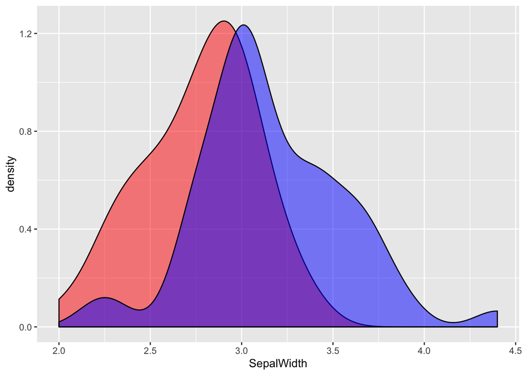

```r
ggplot() +
  geom_density(data = versicolor, aes(x = SepalWidth), fill = "red", alpha = 0.5) +
  geom_density(data = otraSp, aes(x = SepalWidth), fill = "blue", alpha = 0.5)
```

La diferencia entre ambos promedios es de:

```r
(mean_diff <- diff(diference$mean))
```

```
## [1] -0.394
```

### 1. Método de permutaciones (también llamado de aleatorización o *randomizations*):

Si ambas muestras pertenecieran a una misma distribución (hipótesis nula), ¿qué tan común sería tener nuestra diferencia entre promedios?

Para esto combinamos ambas muestras y muestramos al azar dos grupos (mitades). Con estas dos muestras comparamos la diferencia entre sus promedios En el caso de este ejemplo repetimos el muestreo 100 000 veces y creamos un histograma con esas diferencias.

```r
species_sample <- function(analysis){
  other1_indx <- sample(1:nrow(analysis), 50, replace = FALSE)
  other1_df <- analysis$SepalWidth[other1_indx]
  other2_df <- analysis$SepalWidth[-other1_indx]
  mean(other1_df) - mean(other2_df)
}

permut_results <- replicate(10e4, species_sample(analysis))
```

Con un histograma se muestra la distribución de las diferencias entre promedios de nuestros 100 000 (re)muestreos: La línea roja representa el valor de la diferencia encontrada entre el promedio de *versicolor* y nuestra *otra especie*.

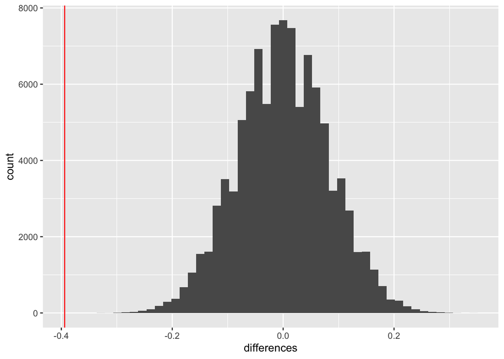

```r
tibble(differences = permut_results) %>%
  ggplot(aes(differences)) +
  geom_histogram(bins = 50) +
  geom_vline(xintercept = diff(diference$mean), colour = "red")
```

La distribución de las permutaciones no logró acercarse a la diferencia medida entre *versicolor* y nuestra *otra especie*. Podemos ver esto más claramente con el resumen de la distribución de las permutaciones:

```r
summary(permut_results)
```

```
##      Min.   1st Qu.    Median      Mean   3rd Qu.      Max.
## -3.34e-01 -5.40e-02 -2.00e-03 -3.60e-06  5.40e-02  3.38e-01
```

Según el histograma y resumen de la distribución, no hubo ningún caso en que las permutaciones igualaran o sobrepasaran nuestro valor medido.

```r
length(permut_results[permut_results < diff(diference$mean)])
```

```
## [1] 0
```

Si tomamos en cuenta que ninguna permutación de un total de 100000 lograron alcanzar la diferencia medida, podemos decir entonces que existe una probabilidad muy baja (menor a 1/100000) de que la diferencia medida entre los promedios de *versicolor* y *otra especie* se produzca al azar si ambas distribuciones pertenecieran a una misma especie.

En otras palabras, tenemos gran certeza de que ambas muestras provienen de distribuciones distintas.

```r
t.test(versicolor$SepalWidth, otraSp$SepalLength)
```

```
##
##  One Sample t-test
##
## data:  versicolor$SepalWidth
## t = 62.419, df = 49, p-value < 2.2e-16
## alternative hypothesis: true mean is not equal to 0
## 95 percent confidence interval:
##  2.68082 2.85918
## sample estimates:
## mean of x
##      2.77
```

### 3. Enfoque frecuentista: modelo de regresión lineal.

En este caso modelaremos el valor del ancho del sépalo con respecto a cada una de las especies. Para esto la intersección del modelo tendrá el valor del promedio de una especie (en este caso *otra especie*) y el coeficiente (pendiente) representa la diferencia entre esa *otra especie* y *versicolor*.

```r
#convertimos a setosa a valor 1 y a otra especie a valor 0
analysis_classified <- analysis %>%
  mutate(sp_id = as.integer(if_else(Species == "versicolor", 1, 0))) %>%
  select(sp_id, SepalWidth)

linmod <- lm(SepalWidth ~ sp_id, data = analysis_classified)
summary(linmod)
```

```
##
## Call:
## lm(formula = SepalWidth ~ sp_id, data = analysis_classified)
##
## Residuals:
##     Min      1Q  Median      3Q     Max
## -0.9640 -0.1935  0.0300  0.2300  1.2360
##
## Coefficients:
##             Estimate Std. Error t value Pr(>|t|)
## (Intercept)  3.16400    0.05099  62.051  < 2e-16 ***
## sp_id       -0.39400    0.07211  -5.464 3.54e-07 ***
## ---
## Signif. codes:  0 '***' 0.001 '**' 0.01 '*' 0.05 '.' 0.1 ' ' 1
##
## Residual standard error: 0.3606 on 98 degrees of freedom
## Multiple R-squared:  0.2335, Adjusted R-squared:  0.2257
## F-statistic: 29.85 on 1 and 98 DF,  p-value: 3.541e-07
```

Podemos ver que el valor de la intersección *(Intercept)* es el mismo valor del promedio de *otra especie* previamente calculado, y el valor del coeficiente (*sp_id*) la diferencia entre *otra especie* y *versicolor*. Vemos también en la columna *Pr(>|t|)* que la probabilidad que el valor del coeficiente se produzca al azar en caso de que ambas muestras provinieran de una misma distribución es sumamente bajo.

Nota: Vale aclarar que la función *lm* de R no necesita que la variable categórica (especie) sea conviertida en numérica (1 para *versicolor* y 0 para *otraSP*), pero preferimos hacera desde el inicio ya que esta transformación es necesaria para cuando más adelante utilizemos las funciones del paquete *Rethinking* en la creación del modelo bayesiano.

### 4. Enfoque bayesiano utilizando el paquete [*Rethinking*](https://github.com/rmcelreath/statrethinking_winter2019#r-package) como interface a la herramienta *Stan*.

La idea del modelo bayesiano de este ejemplo es similar al modelo de regresión lineal utilizado en el apartado anterior, pero, como en todo modelo bayesiano, se generará una distribución *posterior* de los valores de cada variable.

El modelo se especifíca en el chunk siguiente y se lee como: El valor del ancho del sépalo proviene de una distribución normal donde el promedio está en función de la regresión lineal, donde *a* (la intersección) es el valor promedio de *otra especie* y *b* es el promedio de la diferencia entre *otra especie* y *versicolor*. Como previos de *a* y *b* utilizamos distribuciones normales con promedio 4 y 1 respectivamente, y desviaciones estándard iguales a 1. Para la desviación estándard de la verosimilitud, utilizamos una distribución exponencial con parámetro igual a 1, asegurándonos así que los valores serán únicamente positivos y facilitandole al algoritmo MCMC encontrar los valores de los parámetros.

```r
library(rethinking)

diff_mod <- ulam(
  alist(
    SepalWidth ~ dnorm(mu, sigma),
    mu <- a + b*sp_id,
    a ~ dnorm(4, 1),
    b ~ dnorm(1, 1),
    sigma ~ dexp(1)
  ), data = analysis_classified, chains=4)
```

Con la función *summary* vemos el resumen de los valores de cada variable:

```r
summary(diff_mod)
```

```
## Inference for Stan model: 923b38a669fcca7312992e9c941cdf79.
## 4 chains, each with iter=1000; warmup=500; thin=1;
## post-warmup draws per chain=500, total post-warmup draws=2000.
##
##        mean se_mean   sd  2.5%   25%   50%   75% 97.5% n_eff Rhat
## a      3.16    0.00 0.05  3.06  3.13  3.16  3.20  3.27   987 1.01
## b     -0.39    0.00 0.08 -0.54 -0.44 -0.39 -0.34 -0.24   974 1.01
## sigma  0.36    0.00 0.03  0.32  0.35  0.36  0.38  0.42  1098 1.00
## lp__  48.71    0.05 1.36 45.07 48.15 49.09 49.69 50.20   877 1.00
##
## Samples were drawn using NUTS(diag_e) at Sat Oct  5 15:59:11 2019.
## For each parameter, n_eff is a crude measure of effective sample size,
## and Rhat is the potential scale reduction factor on split chains (at
## convergence, Rhat=1).
```

Vemos en la columna *mean* que el valor de *b* (diferencia entre promedios) es similar al del modelo lineal frecuentista, pero a diferencia del otro, tenemos una distribución completa de esa variable. El intervalo de credibilidad para esa variable se muestra en las columnas de percentiles (con el signo de porcentaje al lado) y según estos valores su rango no incluye al cero, por lo que llegamos a la misma conclusión que con los métodos anteriores.

Otra manera en que podemos calcular esta comparación entre promedios es creando distribuciones para los promedios de cada una de las especies.

Para esto debemos asignar un índice distinto a cero para cada especie y crear un modelo donde cada una de las especies tendrá una intersección distinta. Como índice damos a *Versicolor* un valor igual a 2 y *otra especie* de 1.

Notese que para el paquete Rethinking, los números asignados a estos índices deben de ser enteros.

```r
an_reth2 <- analysis %>%
  mutate(Sp = as.integer(if_else(Species == "versicolor", 2, 1))) %>%
  select(Sp, SepalWidth)

mod_sp <- ulam(
  alist(
    SepalWidth ~ dnorm(mu, sigma),
    mu <- a[Sp],
    sigma <- b[Sp],
    a[Sp] ~ dnorm(4, 1),
    b[Sp] ~ dexp(1)
  ), data = an_reth2, chains=4)
```

Ahora con la función *summary* (o *precis*) vemos el resumen de los valores de cada variable. Se puede notar que las distribuciones de **a1** (distribución del promedio de *otra especie*) y **a2** (distribución del promedio de *Versicolor*) no se sobreponen. En el caso de **a1** el 95% de la distribución se encuentra entre 3.05 y 3.28, mientras que para **a2** va de 2.68 a 2.87.

```r
summary(mod_sp)
```

```
## Inference for Stan model: 8f33ef043c4f63473233930db4f550eb.
## 4 chains, each with iter=1000; warmup=500; thin=1;
## post-warmup draws per chain=500, total post-warmup draws=2000.
##
##       mean se_mean   sd  2.5%   25%   50%   75% 97.5% n_eff Rhat
## a[1]  3.17    0.00 0.06  3.05  3.13  3.17  3.21  3.28  2743    1
## a[2]  2.77    0.00 0.05  2.68  2.74  2.77  2.80  2.87  2033    1
## b[1]  0.41    0.00 0.04  0.34  0.38  0.41  0.43  0.50  2397    1
## b[2]  0.32    0.00 0.04  0.26  0.30  0.32  0.34  0.39  2234    1
## lp__ 48.51    0.06 1.55 44.70 47.77 48.87 49.62 50.37   758    1
##
## Samples were drawn using NUTS(diag_e) at Sat Oct  5 16:00:00 2019.
## For each parameter, n_eff is a crude measure of effective sample size,
## and Rhat is the potential scale reduction factor on split chains (at
## convergence, Rhat=1).
```

Podemos también graficar estas distribuciones utilizando las funciones *plot* y *precis*.

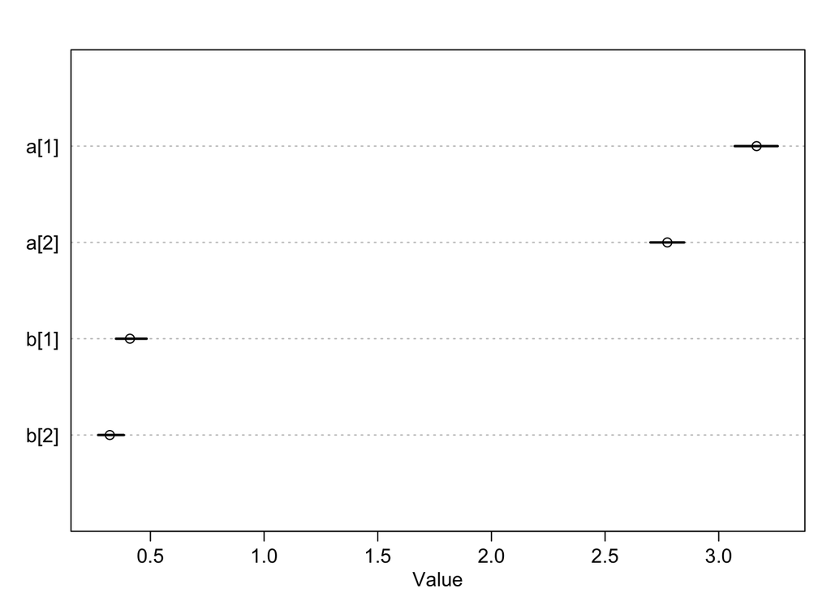

```r
plot(precis(mod_sp, depth = 2))
```

Otra manera de elaborar esta misma comparación de distribuciones es extrayendo valores del modelo y graficando las variables que nos interesan. Para esto tomamos 100000 muestras del modelo creado utilizando la función *extract.samples*.

```r
samples <- extract.samples(mod_sp, n = 100000)
```

Esta función nos genera una lista con cada una de las variables del modelo y dentro de cada uno de los elementos de la lista tenemos una matriz donde las columnas representan los índices utilizados en el modelo, la primer columna son valores modelados para el índice 1 y la segunda para el 2.

Estas muestras representan la distribución de cada una de esas variables, por lo que podemos utilizarlas para graficarlas.

En este caso graficamos las distribuciones marginales para los promedios de especies.

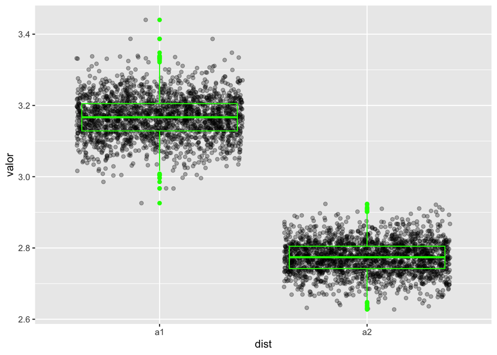

```r
samples_df <- tibble(a1 = samples$a[,1], a2 = samples$a[,2]) %>% gather(key = "dist", value = "valor")

ggplot(samples_df, aes(x = dist, y = valor)) +
  geom_jitter(alpha = 0.3) +
  geom_boxplot(fill = NA, colour = "green")
```

Podemos ver cómo la mayoría de los valores de cada una de las especies se encuentran agrupados alrededor de dos valores distintos, por lo que llegamos a la misma conclusión que con los metodos anteriores.

#### Utilizando el paquete *brms*

Además de la opción de usar el paquete *Rethinking* como interface a *Stan*, también podemos utilizar el paquete *brms*. Se adjunta el código para el mismo análisis utilizando varianzas de una misma distribución.

```r
library(brms)

mod_brms <- brm(
  SepalWidth ~ Species,
  data = analysis
)
```

Los resultados son iguales a los generados con *Rethinking*.

```r
summary(mod_brms)
```

```
##  Family: gaussian
##   Links: mu = identity; sigma = identity
## Formula: SepalWidth ~ Species
##    Data: analysis (Number of observations: 100)
## Samples: 4 chains, each with iter = 2000; warmup = 1000; thin = 1;
##          total post-warmup samples = 4000
##
## Population-Level Effects:
##                   Estimate Est.Error l-95% CI u-95% CI Rhat Bulk_ESS
## Intercept             3.16      0.05     3.06     3.26 1.00     4069
## Speciesversicolor    -0.39      0.07    -0.54    -0.26 1.00     3675
##                   Tail_ESS
## Intercept             2604
## Speciesversicolor     3051
##
## Family Specific Parameters:
##       Estimate Est.Error l-95% CI u-95% CI Rhat Bulk_ESS Tail_ESS
## sigma     0.36      0.03     0.32     0.42 1.00     3428     2846
##
## Samples were drawn using sampling(NUTS). For each parameter, Eff.Sample
## is a crude measure of effective sample size, and Rhat is the potential
## scale reduction factor on split chains (at convergence, Rhat = 1).
```

Con la función *plot* podemos ver las distribuciones de cada parámetro del modelo, además del *trace plot* de las cadenas de Markov.

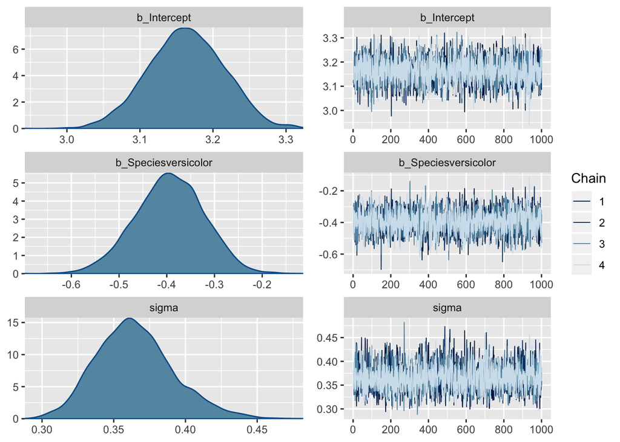

```r
plot(mod_brms)
```